# **Gráficos con ggplot2**

Fecha de publicación

28 de agosto de 2026

# Objetivos del manual

- Comprender la lógica detras de la estructura los gráficos con ggplot2
- Ser capaz de intregrar en un gŕafico diferentes fuentes de información que representen la complejidad de los datos

## ggplot2

- Un paquete de R diseñado específicamente para producir gráficos
- A diferencia de otros paquetes, ggplot2 tiene su propia gramática
- La gramática se basa en la “Gramática de los gráficos” (Wilkinson 2005)
- Módulos independientes que pueden combinarse de muchas formas
- Esta gramática proporciona una gran flexibilidad

## 0.1 Gramática de gráficos

La idea principal es empezar con una capa base de datos brutos y luego añadir más capas de anotaciones y resúmenes estadísticos. El paquete nos permite producir gráficos utilizando la misma estructura de pensamiento que utilizamos al diseñar un análisis, reduciendo la distancia de cómo visualizamos un gráfico en la cabeza y el producto final.

Aprender la gramática no sólo es útil para producir un gráfico de interés, sino también para pensar en otros gráficos más complejos. La ventaja de esta gramática es la posibilidad de crear nuevos gráficos compuestos por nuevas combinaciones de elementos.

## 0.2 Componentes del gráfico

Todos los gráficos ggplot2 contienen los siguientes componentes:

- **Datos** - El objeto R con la información que necesita ser trazada
- **Capas** - Los datos específicos que serán graficados (ej. ‘x’ & ‘y’)
- **Escala** - Rango de datos a incluir
- **Coordenadas** - Sistema de coordenadas (no se utiliza muy a menudo)
- **Parcelas (facets)** - Determina cómo dividir los datos en subparcelas en un multipanel
- **Tema** - Controla el estilo del gráfico

Estos componentes se juntan utilizando “+”.

La sintaxis más habitual incluye los datos dentro de la llamada “ggplot” y una capa “geom_”.

Primero instala/carga el paquete:

**Código**

```r
# install
install.packages("ggplot2")

# load library
library(ggplot2)
```

## 0.3 Gráficos de dispersión

Utilicemos el conjunto de datos “iris” para crear gráficos de dispersión:

**Código**

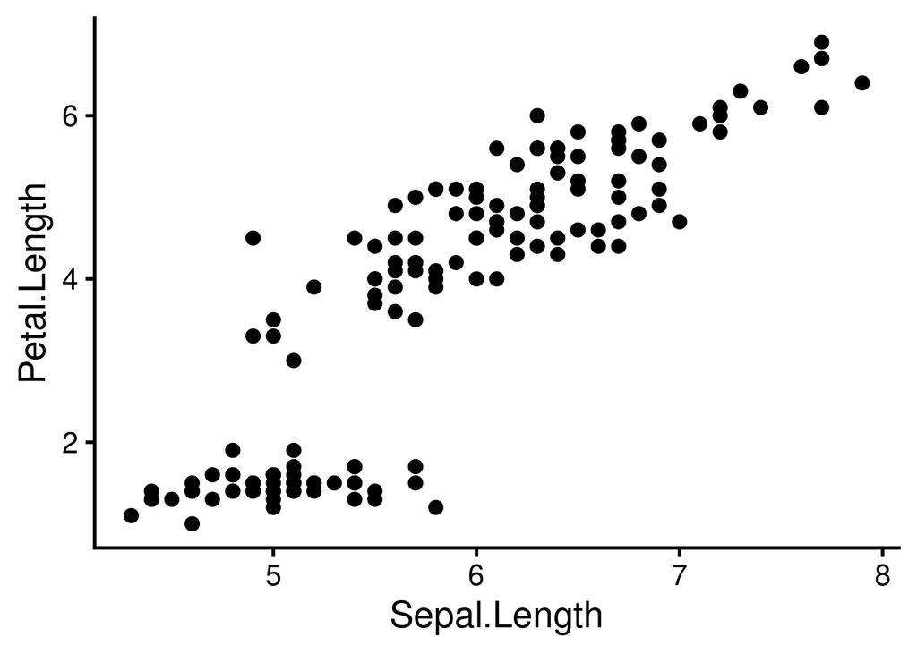

```r
ggplot(data = iris, mapping = aes(x = Sepal.Length, y = Petal.Length)) +
  geom_point()
```

This plot is defined by 3 components: 1. “data”- iris 1. “aes” - Sepal.length vs Petal.length 1. “layer” - Points (geom)

## 0.4 Atributos estéticos

También podemos añadir otros atributos estéticos como el color, la forma y el tamaño. Estos atributos se pueden incluir dentro de `aes()`:

**Código**

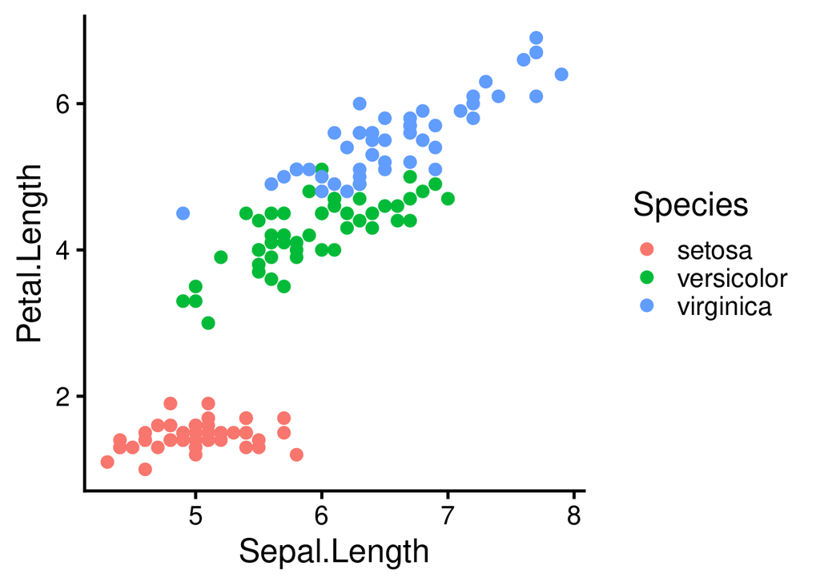

```r
# color by species
ggplot(
  data = iris,
  mapping = aes(x = Sepal.Length, y = Petal.Length, color = Species)
) +
  geom_point()
```

**Código**

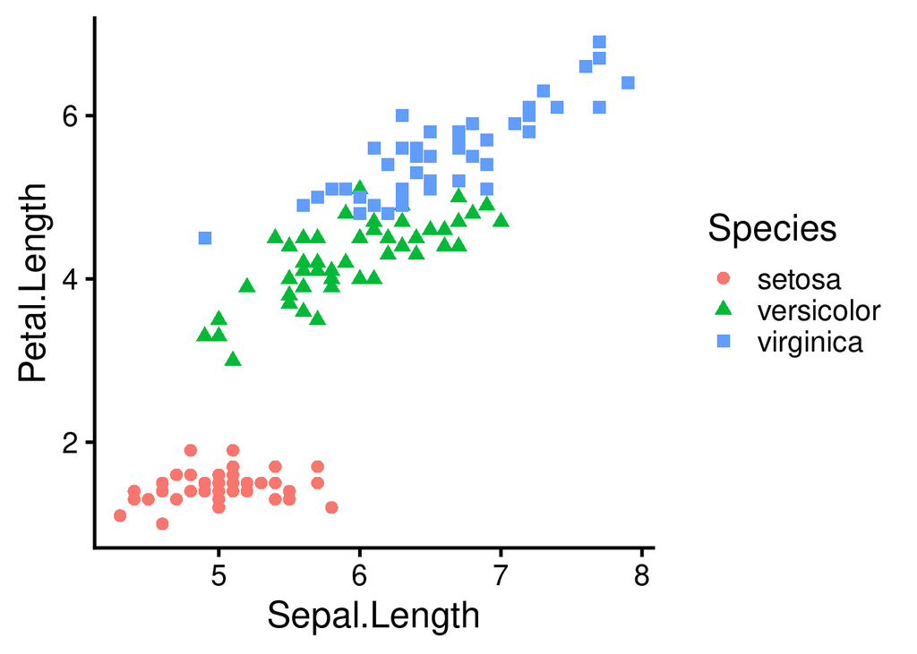

```r
# color and shape by species
ggplot(
  data = iris,
  mapping = aes(
    x = Sepal.Length,
    y = Petal.Length,
    color = Species,
    shape = Species
  )
) +
  geom_point()
```

Tenga en cuenta que los argumentos estéticos también pueden incluirse en la capa “geom”:

**Código**

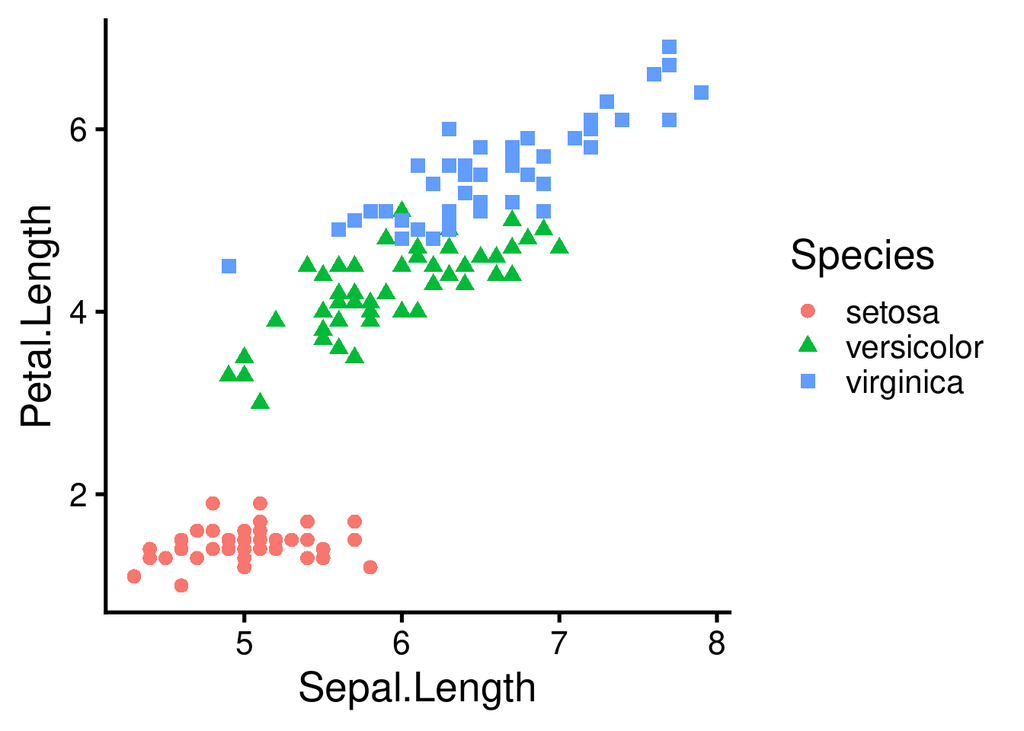

```r
ggplot(
  data = iris,
  mapping = aes(x = Sepal.Length, y = Petal.Length)
) +
  geom_point(aes(color = Species, shape = Species))
```

También podemos incluir un valor fijo:

**Código**

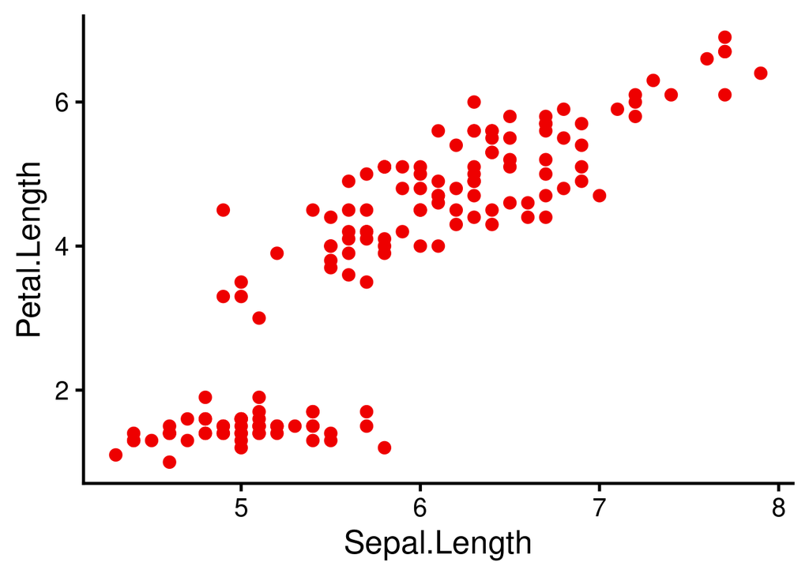

```r
ggplot(
  data = iris,
  mapping = aes(x = Sepal.Length, y = Petal.Length)
) +
  geom_point(color = "red2")
```

Algunos atributos funcionan mejor con algunos tipos de datos:

- Color y forma: variables categóricas
- Tamaño: variables continuas

Ejercicio 1

Utilizando el conjunto de datos “hylaeformis”:

**Código**

```r
# lear desde el sitio del curso
hylaeformis_data <- read.csv(
  paste0("https://raw.githubusercontent.com/maRce10/", "r_avanzado_2023/master/data/hylaeformis_data.csv")
)

# or bajar manualmente y leer copia local
hylaeformis_data <- read.csv("hylaeformis_data.csv", stringsAsFactors = FALSE)

head(hylaeformis_data, 20)
```

1.1 Crear un gráfico de dispersión de duración (“duration”) vs frecuencia promedio (“meanfreq”)

1.2 Añadir un atributo estético para mostrar un color diferente para cada localidad

1.3 Añade otro atributo estético para mostrar el rango de frecuencia dominante (“dfrange”) como tamaño los símbolos

## 0.5 Gráficos multipanel (Facetting)

- Otra forma de visualizar variables categóricas
- Permite crear gráficos multipanel para cada nivel de la variable
- 2 tipos: “grid” & “wrap”

**Código**

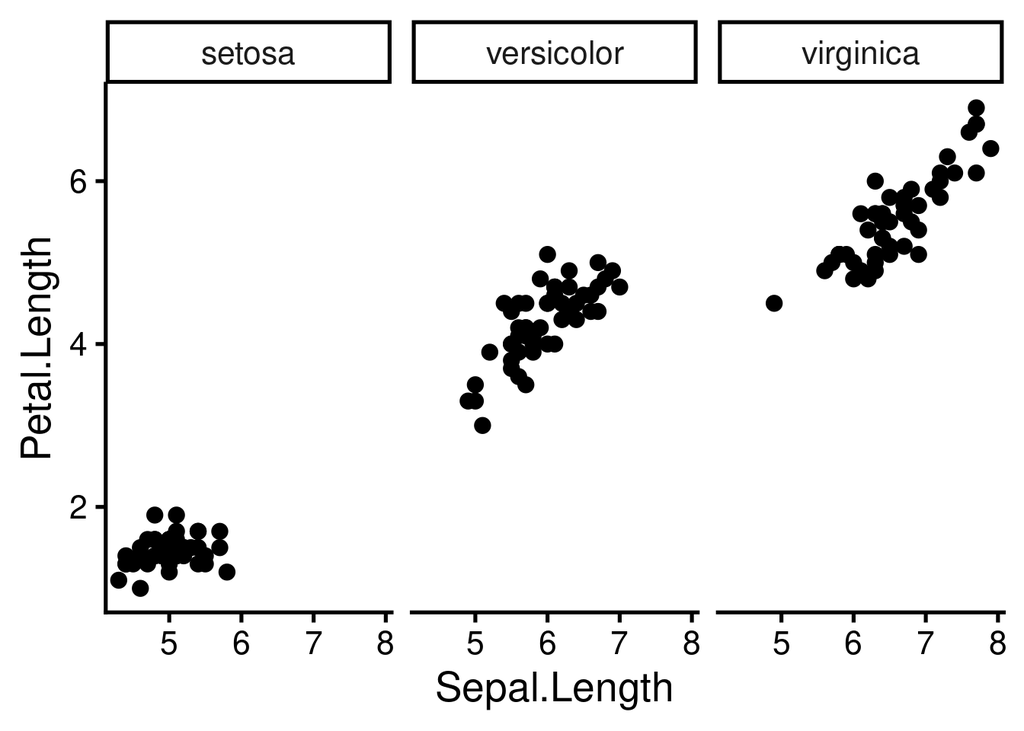

```r
ggplot(iris, aes(Sepal.Length, Petal.Length)) +
  geom_point() +
  facet_wrap(~Species)
```

**Código**

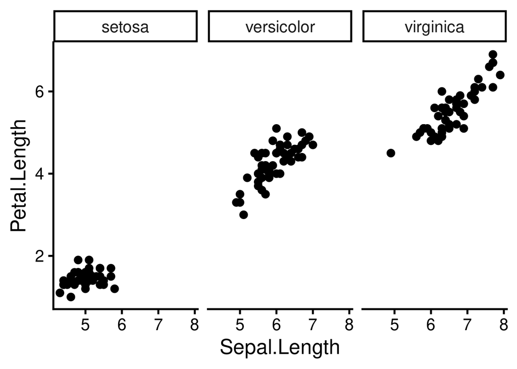

```r
# o

ggplot(iris, aes(Sepal.Length, Petal.Length)) +
  geom_point() +
  facet_grid(~Species)
```

La escala puede ser fija o libre para los ejes *x* e *y*, y puede modificarse el número de columnas y filas:

**Código**

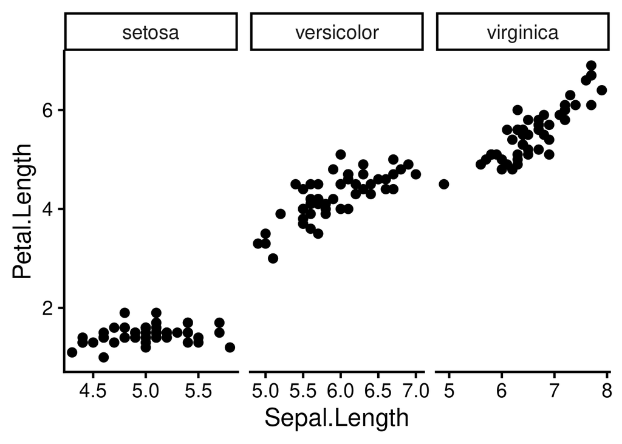

```r
# free x
ggplot(iris, aes(Sepal.Length, Petal.Length)) +
  geom_point() +
  facet_wrap(~Species, scales = "free_x")
```

**Código**